# Analysis and Forecasting of CDC Weekly Disease Surveillance Data

## **Analysis and Forecasting of CDC Weekly Disease Surveillance Data**

**Project Description**

This project provides a comprehensive exploratory and predictive analysis of weekly disease surveillance data from the CDC’s National Notifiable Diseases Surveillance System (NNDSS). Using the dataset extracted on September 24, 2025, the project demonstrates Exploratory Data Analysis (EDA), forecasting, and visualization techniques applied to public health data. Key outcomes include identification of trends, anomalies, seasonality patterns, and preparation of structured outputs for reporting or dashboards.

**Project Objectives**

**Data Collection & Dataset**

- Source: CDC’s National Notifiable Diseases Surveillance System (NNDSS) weekly data, latest update on September 24, 2025.

https://data.cdc.gov/NNDSS/NNDSS-Weekly-Data/x9gk-5huc/data_preview

- Fields: Current week, Previous 52 week Max, Cumulative YTD Current MMWR Year, Cumulative YTD Previous MMWR Year, Label (disease name), Reporting Area, MMWR year/week, optional lat/lon for geospatial mapping.

# **Data Preparation**

First, we import all packages we will be using in this pipeline

```python
# -------------------------
# Imports
# -------------------------

# Core Python libraries for data handling
import pandas as pd
import numpy as np
import datetime as dt
import warnings

# Visualization libraries
import matplotlib.pyplot as plt
import seaborn as sns

# Display enhancements
from IPython.display import display, HTML
```

This block standardizes visualization parameters to ensure consistent, high-quality plots and readable notebook outputs.

```python
# -------------------------
# Visual and display settings
# -------------------------

# Turn off warnings to keep output clean
warnings.filterwarnings("ignore")

# Seaborn Theme
sns.set_theme(style="whitegrid", palette="deep")

# Matplotlib
plt.rcParams.update({
    'figure.dpi': 110,
    'figure.figsize': (12, 5),
    'axes.titlesize': 14,
    'axes.labelsize': 12,
    'lines.linewidth': 2
})

# Pandas Display
pd.set_option('display.max_columns', None)
pd.set_option('display.max_rows', 100)
pd.set_option('display.float_format', '{:.2f}'.format)
```

Loading NNDSS Weekly Data

```python
# -------------------------
# Load dataset
# -------------------------

# Load the dataset as strings initially to avoid type issues
RAW_PATH = "/content/NNDSS_Weekly_Data.csv"
df = pd.read_csv(RAW_PATH, dtype=str, engine='python', )
df_raw = df.copy()

# Remove any leading/trailing whitespace from column names
df.columns = df.columns.str.strip()

# Quick check
print(f"Shape: {df.shape[0]} rows x {df.shape[1]} columns")
display(df.head())
```

```
Shape: 1547980 rows x 16 columns
```

|  | Reporting Area | Current MMWR Year | MMWR WEEK | Label | Current week | Current week, flag | Previous 52 week Max | Previous 52 weeks Max, flag | Cumulative YTD Current MMWR Year | Cumulative YTD Current MMWR Year, flag | Cumulative YTD Previous MMWR Year | Cumulative YTD Previous MMWR Year, flag | LOCATION1 | LOCATION2 | sort_order | geocode |
| --- | --- | --- | --- | --- | --- | --- | --- | --- | --- | --- | --- | --- | --- | --- | --- | --- |
| 0 | US RESIDENTS | 2022 | 1 | Anthrax | NaN | - | 0 | - | NaN | - | NaN | - | NaN | US RESIDENTS | 20220100001 | NaN |
| 1 | NEW ENGLAND | 2022 | 1 | Anthrax | NaN | - | 0 | - | NaN | - | NaN | - | NaN | NEW ENGLAND | 20220100002 | NaN |
| 2 | CONNECTICUT | 2022 | 1 | Anthrax | NaN | - | 0 | - | NaN | - | NaN | - | CONNECTICUT | NaN | 20220100003 | POINT (-72.738288 41.575155) |
| 3 | MAINE | 2022 | 1 | Anthrax | NaN | - | 0 | - | NaN | - | NaN | - | MAINE | NaN | 20220100004 | POINT (-69.06137 45.117911) |
| 4 | MASSACHUSETTS | 2022 | 1 | Anthrax | NaN | - | 0 | - | NaN | - | NaN | - | MASSACHUSETTS | NaN | 20220100005 | POINT (-71.481104 42.151077) |

We then clean and preprocess our dataset following the guidelines from the CDC Website. Including Converting numeric columns, splitting geocodes to latitude and longhitude, removing duplicates, and handling missing and special values.

```python
# -------------------------
# Data Cleaning & Preprocessing
# -------------------------

# Convert numeric columns

numeric_cols = [
    "Current week",
    "Previous 52 week Max",
    "Cumulative YTD Current MMWR Year",
    "Cumulative YTD Previous MMWR Year",
    "MMWR Week",
    "MMWR Year"
]

for col in numeric_cols:
    if col in df.columns:
        df[col] = (
            df[col]
            .astype(str)
            .str.replace(",", "", regex=False)        # remove thousand separators
            .str.replace(r"[^\d.-]", "", regex=True)  # remove CDC special markers
        )
        df[col] = pd.to_numeric(df[col], errors="coerce")

# Strip whitespace for consistency in string columns
for col in df.select_dtypes(include='object').columns:
    df[col] = df[col].str.strip()

# Parse geocodes
if 'geocode' in df.columns:
    def parse_point(point_str):
        try:
            lon, lat = map(float, str(point_str).replace('POINT (','').replace(')','').split())
            return lat, lon
        except:
            return np.nan, np.nan

    latlon = df['geocode'].apply(parse_point)
    df['lat'] = latlon.apply(lambda t: t[0])
    df['lon'] = latlon.apply(lambda t: t[1])
else:
    df['lat'] = np.nan
    df['lon'] = np.nan

# Remove duplicate rows
before = len(df)
df = df.drop_duplicates().reset_index(drop=True)
after = len(df)
print(f"Removed {before - after} duplicate rows. Remaining: {after}")

# Filter weekly case values
df_clean = df[df['Current week'].notna()].copy()
print(f"Cleaned dataset ready for analysis: {len(df_clean)} rows with reported weekly cases.")

# Missing values
missing_pct = (df_clean.isnull().sum() / len(df_clean) * 100).sort_values(ascending=False)
print("\n% Missing Values (Top 10 Columns):")
display(missing_pct.head(10))

# Summary statistics for numeric fields
existing_numeric = [col for col in numeric_cols if col in df_clean.columns]
print("\nSummary Statistics for Numeric Columns:")
display(df_clean[existing_numeric].describe())
```

```
Removed 0 duplicate rows. Remaining: 1547980
Cleaned dataset ready for analysis: 158680 rows with reported weekly cases.

% Missing Values (Top 10 Columns):
```

|  | 0 |
| --- | --- |
| LOCATION2 | 59.19 |
| LOCATION1 | 40.81 |
| lon | 40.46 |
| lat | 40.46 |
| geocode | 40.46 |
| Current week, flag | 22.54 |
| Cumulative YTD Current MMWR Year, flag | 22.54 |
| Previous 52 weeks Max, flag | 22.48 |
| Cumulative YTD Previous MMWR Year, flag | 22.02 |
| Previous 52 week Max | 9.58 |

**dtype:** float64

```
Summary Statistics for Numeric Columns:
```

|  | Current week | Previous 52 week Max | Cumulative YTD Current MMWR Year | Cumulative YTD Previous MMWR Year |
| --- | --- | --- | --- | --- |
| count | 158680.00 | 143476.00 | 158680.00 | 146323.00 |
| mean | 102.21 | 249.75 | 4898.30 | 6304.96 |
| std | 717.46 | 1657.71 | 41912.08 | 52739.06 |
| min | 1.00 | 0.00 | 1.00 | 1.00 |
| 25% | 1.00 | 8.00 | 37.00 | 40.00 |
| 50% | 4.00 | 24.00 | 177.00 | 187.00 |
| 75% | 22.00 | 85.00 | 921.25 | 1036.00 |
| max | 18198.00 | 37668.00 | 1483270.00 | 1654349.00 |

Missing values in the NNDSS weekly dataset are expected because of how public health surveillance works in the United States.

- Not every disease is legally reportable in every jurisdiction, so many states do not submit counts at all for certain conditions — these appear as blank cells rather than zeros. Even when a disease is reportable, jurisdictions often skip weeks, revise earlier data, or delay submissions, which naturally produces gaps in weekly counts.
- Some fields — such as “Previous 52 week Max” or cumulative year-to-date totals—can only be calculated after enough historical data exists, so they remain empty for newer conditions or early in the year.
- LOCATION2 and geocodes are optional fields and are often omitted entirely by states.

Because these gaps reflect policy, reporting practices, and the structure of the surveillance system — not data corruption — this level of missingness is acceptable and expected. The key is to analyze the data with this context in mind, filtering by disease, jurisdiction, and time period rather than assuming all fields apply everywhere.

Next step is to prepare our dataset for analysis by parsing to ensure our fields are of the correct data types

```python
# -------------------------
# Convert to Calendar Date
# -------------------------

# Ensure consistent naming
df_clean = df_clean.rename(columns={
    "Current MMWR Year": "MMWR Year",
    "MMWR WEEK": "MMWR Week"
}) if "Current MMWR Year" in df_clean.columns else df_clean

# Ensure year/week are numeric so we can create date variable
df_clean["MMWR Year"] = pd.to_numeric(df_clean["MMWR Year"], errors="coerce")
df_clean["MMWR Week"] = pd.to_numeric(df_clean["MMWR Week"], errors="coerce")

# Build an ISO week string like "2024-W05-1" Using Monday as the anchor point for each epidemiological week
iso_strings = (
    df_clean["MMWR Year"].astype("Int64").astype(str)
    + "-W"
    + df_clean["MMWR Week"].astype("Int64").astype(str).str.zfill(2)
    + "-1"  # Monday anchor
)

# Convert ISO week string → actual timestamp
df_clean["date"] = pd.to_datetime(
    iso_strings,
    format="%G-W%V-%u",
    errors="coerce"
)

# Quick check
print("Date range:", df_clean["date"].min(), "to", df_clean["date"].max())
display(df_clean[["MMWR Year", "MMWR Week", "date"]].head())
```

```
Date range: 2022-01-03 00:00:00 to 2025-09-15 00:00:00
```

|  | MMWR Year | MMWR Week | date |
| --- | --- | --- | --- |
| 980 | 2022 | 1 | 2022-01-03 |
| 981 | 2022 | 1 | 2022-01-03 |
| 983 | 2022 | 1 | 2022-01-03 |
| 984 | 2022 | 1 | 2022-01-03 |
| 987 | 2022 | 1 | 2022-01-03 |

MMWR weeks (used by CDC) don’t always line up with standard calendar weeks, so converting MMWR Year + MMWR WEEK → a proper date is essential for time-series analysis, forecasting, visualization, and trend comparison. To do this correctly, we rely on ISO week formatting, which matches how CDC structures epidemiological weeks.

# **Feature Engineering**

This section transforms raw NNDSS weekly data into a format suitable for analysis, visualization, and forecasting. Aggregating to the national level per disease clarifies trends, seasonality, anomalies, and growth patterns.

```python
# -------------------------
# Feature Engineering
# -------------------------

CURRENT = 'Current week'
MAX52   = 'Previous 52 week Max'
CUMYTD  = 'Cumulative YTD Current MMWR Year'

# Aggregate to national-level weekly series per disease
agg = (
    df_clean.groupby(['Label', 'date'], as_index=False)
            [[CURRENT, MAX52, CUMYTD]]
            .sum()
            .sort_values(['Label', 'date'])
            .reset_index(drop=True)
)

# Insert missing weeks per disease
full_series = []
for disease, temp in agg.groupby('Label'):
    full_range = pd.DataFrame({
        'date': pd.date_range(temp['date'].min(), temp['date'].max(), freq='W-MON')
    })
    merged = full_range.merge(temp, on='date', how='left')
    merged['Label'] = disease
    merged[[CURRENT, MAX52, CUMYTD]] = merged[[CURRENT, MAX52, CUMYTD]].fillna(0)
    full_series.append(merged)

agg = pd.concat(full_series, ignore_index=True).sort_values(['Label', 'date'])

# Lag features (1–4 week lags)
for lag in range(1, 5):
    agg[f'lag_{lag}'] = agg.groupby('Label')[CURRENT].shift(lag).fillna(0)

# Week-over-week growth rate
agg['growth_rate'] = agg.groupby('Label')[CURRENT].pct_change()

# Contribution to year-to-date (%)
agg['pct_of_ytd'] = agg[CURRENT] / agg[CUMYTD].replace(0, np.nan)

# 3-week & 8-week rolling averages
agg['roll3'] = agg.groupby('Label')[CURRENT].rolling(3, min_periods=1).mean().reset_index(level=0, drop=True)
agg['roll8'] = agg.groupby('Label')[CURRENT].rolling(8, min_periods=1).mean().reset_index(level=0, drop=True)

# Epidemiological week features
agg['weekofyear'] = agg['date'].dt.isocalendar().week.astype(int)
agg['year']       = agg['date'].dt.year.astype(int)

# Flag very-rare diseases (will be excluded from forecasting)
disease_stats = (
    agg.groupby('Label')[CURRENT]
       .agg(['sum', lambda x: (x > 0).sum()])
       .rename(columns={'<lambda_0>': 'non_zero_weeks'})
)

rare_diseases = disease_stats[
    (disease_stats['sum'] < 100) |
    (disease_stats['non_zero_weeks'] < 30)
].index.tolist()

agg['is_rare'] = agg['Label'].isin(rare_diseases)

# Quick Check
print(f"Identified {len(rare_diseases)} rare diseases (flagged for exclusion in forecasting).")
display(agg.head())
```

```
Identified 31 rare diseases (flagged for exclusion in forecasting).
```

|  | date | Label | Current week | Previous 52 week Max | Cumulative YTD Current MMWR Year | lag_1 | lag_2 | lag_3 | lag_4 | growth_rate | pct_of_ytd | roll3 | roll8 | weekofyear | year | is_rare |
| --- | --- | --- | --- | --- | --- | --- | --- | --- | --- | --- | --- | --- | --- | --- | --- | --- |
| 0 | 2022-06-20 | Arboviral diseases, Chikungunya virus disease | 4.00 | 7.00 | 27.00 | 0.00 | 0.00 | 0.00 | 0.00 | NaN | 0.15 | 4.00 | 4.00 | 25 | 2022 | False |
| 1 | 2022-06-27 | Arboviral diseases, Chikungunya virus disease | 0.00 | 0.00 | 0.00 | 4.00 | 0.00 | 0.00 | 0.00 | -1.00 | NaN | 2.00 | 2.00 | 26 | 2022 | False |
| 2 | 2022-07-04 | Arboviral diseases, Chikungunya virus disease | 0.00 | 0.00 | 0.00 | 0.00 | 4.00 | 0.00 | 0.00 | NaN | NaN | 1.33 | 1.33 | 27 | 2022 | False |
| 3 | 2022-07-11 | Arboviral diseases, Chikungunya virus disease | 0.00 | 0.00 | 0.00 | 0.00 | 0.00 | 4.00 | 0.00 | NaN | NaN | 0.00 | 1.00 | 28 | 2022 | False |
| 4 | 2022-07-18 | Arboviral diseases, Chikungunya virus disease | 0.00 | 0.00 | 0.00 | 0.00 | 0.00 | 0.00 | 4.00 | NaN | NaN | 0.00 | 0.80 | 29 | 2022 | False |

# **Data Analysis**

In this section, we will explore and analyze our dataset to provide helpful information and recommendations regarding disease behavior.

1. **Forecast Weekly Cases** - Predict weekly case counts for the 5 most common disease/condition to anticipate outbreaks or seasonal trends.

```
Top 5 Labels: ['Chlamydia trachomatis infection', 'Gonorrhea', 'Campylobacteriosis', 'Hepatitis C, chronic, Probable', 'Salmonellosis (excluding Salmonella Typhi infection and Salmonella Paratyphi infection)']
```

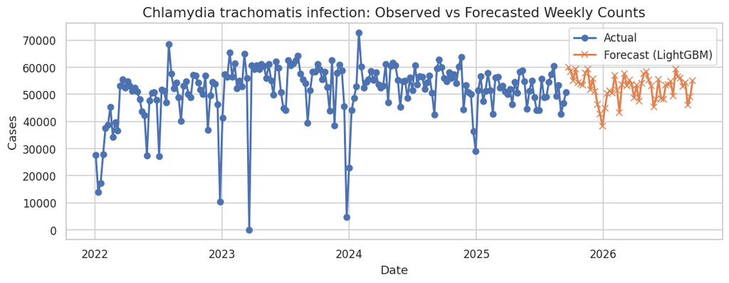

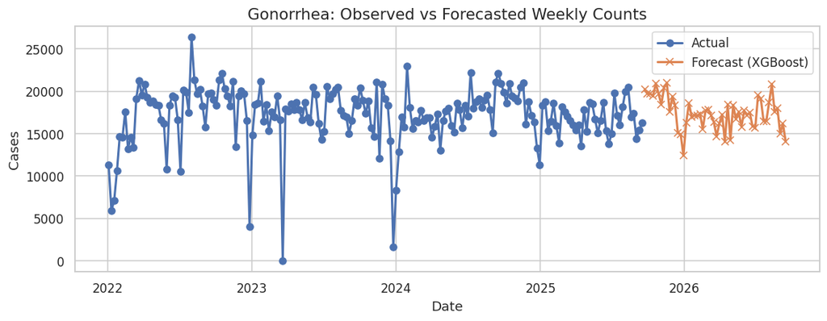

[figure not shown]

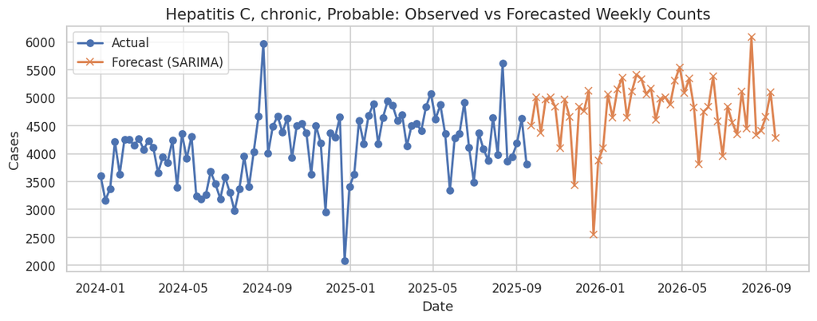

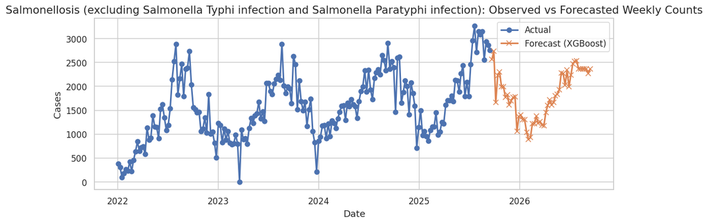

```
Forecast Summary:
```

|  | Label | Model | MAPE | RMSE | Forecast Accuracy (%) | Model Details |
| --- | --- | --- | --- | --- | --- | --- |
| 11 | Campylobacteriosis | XGBoost | 0.07 | 321.68 | 92.88 | {'Features': ['lag_1', 'lag_2', 'lag_3', 'lag_... |
| 10 | Campylobacteriosis | LightGBM | 0.10 | 469.94 | 90.07 | {'Features': ['lag_1', 'lag_2', 'lag_3', 'lag_... |
| 8 | Campylobacteriosis | SARIMA | 0.18 | 557.57 | 81.81 | {'order': (1, 1, 1), 'seasonal_order': (1, 1, ... |
| 9 | Campylobacteriosis | ETS | 0.20 | 594.92 | 80.21 | {'trend': 'add', 'seasonal': 'add', 'period': 52} |
| 2 | Chlamydia trachomatis infection | LightGBM | 0.06 | 3584.31 | 94.36 | {'Features': ['lag_1', 'lag_2', 'lag_3', 'lag_... |
| 3 | Chlamydia trachomatis infection | XGBoost | 0.06 | 4237.00 | 93.64 | {'Features': ['lag_1', 'lag_2', 'lag_3', 'lag_... |
| 1 | Chlamydia trachomatis infection | ETS | 0.12 | 8634.96 | 88.45 | {'trend': 'add', 'seasonal': 'add', 'period': 52} |
| 0 | Chlamydia trachomatis infection | SARIMA | 0.16 | 8664.30 | 84.42 | {'order': (1, 1, 1), 'seasonal_order': (1, 1, ... |
| 7 | Gonorrhea | XGBoost | 0.06 | 1149.94 | 94.05 | {'Features': ['lag_1', 'lag_2', 'lag_3', 'lag_... |
| 6 | Gonorrhea | LightGBM | 0.06 | 1353.08 | 93.57 | {'Features': ['lag_1', 'lag_2', 'lag_3', 'lag_... |
| 4 | Gonorrhea | SARIMA | 0.10 | 2035.47 | 90.16 | {'order': (1, 1, 1), 'seasonal_order': (1, 1, ... |
| 5 | Gonorrhea | ETS | 0.10 | 2519.73 | 89.62 | {'trend': 'add', 'seasonal': 'add', 'period': 52} |
| 12 | Hepatitis C, chronic, Probable | SARIMA | 0.11 | 462.46 | 89.02 | {'order': (1, 1, 1), 'seasonal_order': (1, 1, ... |
| 15 | Hepatitis C, chronic, Probable | XGBoost | 0.12 | 620.43 | 87.65 | {'Features': ['lag_1', 'lag_2', 'lag_3', 'lag_... |
| 14 | Hepatitis C, chronic, Probable | LightGBM | 0.14 | 692.06 | 86.12 | {'Features': ['lag_1', 'lag_2', 'lag_3', 'lag_... |
| 13 | Hepatitis C, chronic, Probable | ETS | NaN | NaN | NaN | Cannot compute initial seasonals using heurist... |
| 19 | Salmonellosis (excluding Salmonella Typhi infe... | XGBoost | 0.13 | 320.88 | 86.93 | {'Features': ['lag_1', 'lag_2', 'lag_3', 'lag_... |
| 18 | Salmonellosis (excluding Salmonella Typhi infe... | LightGBM | 0.13 | 321.89 | 86.99 | {'Features': ['lag_1', 'lag_2', 'lag_3', 'lag_... |
| 17 | Salmonellosis (excluding Salmonella Typhi infe... | ETS | 0.20 | 348.93 | 80.15 | {'trend': 'add', 'seasonal': 'add', 'period': 52} |
| 16 | Salmonellosis (excluding Salmonella Typhi infe... | SARIMA | 0.25 | 443.50 | 74.98 | {'order': (1, 1, 1), 'seasonal_order': (1, 1, ... |

```python
# ============================================
# Analysis 1: Forecast Weekly Cases
# ============================================

from sklearn.metrics import mean_absolute_percentage_error, mean_squared_error
from statsmodels.tsa.holtwinters import ExponentialSmoothing
from statsmodels.tsa.statespace.sarimax import SARIMAX
import lightgbm as lgb
import xgboost as xgb
import warnings
from statsmodels.tools.sm_exceptions import ValueWarning

weekly_col = "Current week"

# Identify top 5 high-volume diseases
if "top5_labels" not in globals():
    top5_labels = (
        agg.groupby("Label")[weekly_col]
           .sum()
           .sort_values(ascending=False)
           .head(5)
           .index
           .tolist()
    )
print("Top 5 Labels:", top5_labels)


# Metrics function
def compute_metrics(y_true, y_pred):
    """Return MAPE, RMSE, and accuracy."""
    mape = mean_absolute_percentage_error(y_true, y_pred)
    rmse = np.sqrt(mean_squared_error(y_true, y_pred))
    accuracy = 100 * (1 - mape)
    return mape, rmse, accuracy

# Additional features and functions for forecasting
def add_ml_features(df):
    """Add lag, rolling, and seasonal features for ML models."""
    df = df.copy()
    for lag in range(1, 5):
        if f"lag_{lag}" not in df.columns:
            df[f"lag_{lag}"] = df["y"].shift(lag)

    df["roll_3w"] = df["roll3"] if "roll3" in df.columns else df["y"].rolling(3).mean()
    df["roll_8w"] = df["roll8"] if "roll8" in df.columns else df["y"].rolling(8).mean()

    df["week_of_year"] = df["weekofyear"] if "weekofyear" in df.columns else df["ds"].dt.isocalendar().week
    if "year" not in df.columns:
        df["year"] = df["ds"].dt.year

    return df

def fit_forecasts(series, forecast_horizon=52):
    """Fit SARIMA, ETS, LightGBM, and XGBoost forecasts."""
    results = {}
    ts = series["y"].astype(float)
    ts.index = series["ds"]

    # SARIMA
    try:
        sarima = SARIMAX(
            ts,
            order=(1, 1, 1),
            seasonal_order=(1, 1, 1, 52),
            enforce_stationarity=False,
            enforce_invertibility=False,
        ).fit(disp=False)

        sarima_fc = sarima.get_forecast(steps=forecast_horizon).predicted_mean
        metrics = compute_metrics(ts[-forecast_horizon:], sarima_fc) if len(ts) >= forecast_horizon else (np.nan, np.nan, np.nan)

        results["SARIMA"] = {
            "Model": sarima,
            "Forecast": sarima_fc,
            "MAPE": metrics[0],
            "RMSE": metrics[1],
            "Forecast Accuracy (%)": metrics[2],
            "Details": {"order": (1, 1, 1), "seasonal_order": (1, 1, 1, 52)}
        }
    except Exception as e:
        results["SARIMA"] = {"Forecast": None, "Details": str(e)}

    # Exponential Smoothing (ETS)
    try:
        ets = ExponentialSmoothing(ts, trend="add", seasonal="add", seasonal_periods=52).fit()
        ets_fc = ets.forecast(forecast_horizon)
        metrics = compute_metrics(ts[-forecast_horizon:], ets_fc) if len(ts) >= forecast_horizon else (np.nan, np.nan, np.nan)

        results["ETS"] = {
            "Model": ets,
            "Forecast": ets_fc,
            "MAPE": metrics[0],
            "RMSE": metrics[1],
            "Forecast Accuracy (%)": metrics[2],
            "Details": {"trend": "add", "seasonal": "add", "period": 52}
        }
    except Exception as e:
        results["ETS"] = {"Forecast": None, "Details": str(e)}

    # ML Models
    try:
        df_ml = add_ml_features(series).dropna()
        if len(df_ml) > 20:
            features = ["lag_1","lag_2","lag_3","lag_4","roll_3w","roll_8w","week_of_year","year"]
            X = df_ml[features]
            y = df_ml["y"]

            train_X, test_X = X[:-forecast_horizon], X[-forecast_horizon:]
            train_y, test_y = y[:-forecast_horizon], y[-forecast_horizon:]

            forecast_index = pd.date_range(start=series["ds"].iloc[-1]+pd.Timedelta(weeks=1),
                                           periods=forecast_horizon, freq="W-MON")

            # LightGBM
            lgb_model = lgb.LGBMRegressor(verbose=-1)
            lgb_model.fit(train_X, train_y)
            lgb_pred = pd.Series(lgb_model.predict(test_X), index=forecast_index[:len(test_y)])
            mape, rmse, acc = compute_metrics(test_y.values, lgb_pred)
            results["LightGBM"] = {"Model": lgb_model, "Forecast": lgb_pred, "MAPE": mape, "RMSE": rmse, "Forecast Accuracy (%)": acc, "Details": {"Features": features}}

            # XGBoost
            xgb_model = xgb.XGBRegressor(objective="reg:squarederror", verbosity=0)
            xgb_model.fit(train_X, train_y)
            xgb_pred = pd.Series(xgb_model.predict(test_X), index=forecast_index[:len(test_y)])
            mape, rmse, acc = compute_metrics(test_y.values, xgb_pred)
            results["XGBoost"] = {"Model": xgb_model, "Forecast": xgb_pred, "MAPE": mape, "RMSE": rmse, "Forecast Accuracy (%)": acc, "Details": {"Features": features}}

    except Exception as e:
        results["ML"] = {"Forecast": None, "Details": str(e)}

    return results

# Run forecast models
summary_rows = []

for label in top5_labels:
    series = agg[agg["Label"]==label][["date", weekly_col]].rename(columns={"date":"ds", weekly_col:"y"}).reset_index(drop=True)

    if len(series) < 30:
        continue

    series = series.set_index("ds").asfreq("W-MON").reset_index()
    with warnings.catch_warnings():
        warnings.simplefilter("ignore", category=ValueWarning)
        results = fit_forecasts(series, forecast_horizon=52)

    valid = {name:r for name,r in results.items() if r["Forecast"] is not None}
    best_model = min(valid.items(), key=lambda x: x[1]["RMSE"])[0] if valid else None
    best_forecast = valid[best_model]["Forecast"] if valid else None

  # Plot actual vs forecast
    plt.figure(figsize=(12,4))
    plt.plot(series["ds"], series["y"], marker="o", label="Actual")
    if best_forecast is not None:
        plt.plot(best_forecast.index, best_forecast.values, marker="x", label=f"Forecast ({best_model})")
    plt.title(f"{label}: Observed vs Forecasted Weekly Counts")
    plt.xlabel("Date")
    plt.ylabel("Cases")
    plt.legend()
    plt.show()

  # Summary metrics
    for model_name, metrics in results.items():
        summary_rows.append({
            "Label": label,
            "Model": model_name,
            "MAPE": metrics.get("MAPE"),
            "RMSE": metrics.get("RMSE"),
            "Forecast Accuracy (%)": metrics.get("Forecast Accuracy (%)"),
            "Model Details": metrics.get("Details")
        })

# Forecast summary table
summary_df = pd.DataFrame(summary_rows)[["Label","Model","MAPE","RMSE","Forecast Accuracy (%)","Model Details"]]
print("\nForecast Summary:")
display(summary_df.sort_values(["Label","RMSE"]))
```

To forecast weekly disease cases for the 5 most common diseases, 4 forecasting models were fitted to the processed dataset.

- **Seasonal ARIMA** - captures trends, autocorrelation, and repeating seasonal patterns, making it ideal for diseases with clear yearly cycles.
- **Exponential Smoothing** - focuses on smoothing past observations and modeling trend and seasonality directly, performing best on stable, less noisy time series.
- **LightGBM** - uses fast, leaf-wise boosted decision trees that excel on large datasets with many engineered features. It is best when you need very fast training and strong performance on nonlinear, noisy patterns.
- **XGBoost** - uses a more conservative level-wise boosting strategy with strong regularization, making it stable and highly accurate on structured, medium-sized datasets. It’s best when you want reliable generalization and strong performance on nonlinear time-series relationships.

The models are evaluated and compared with their **RMSE**, **MAPE**, and **Forecast Accuracy** for each of the model. The best model is then selected as the one with the lowest RMSE.

Interpretation:

Actionable Insights:

- Seasonal gastrointestinal diseases need proactive resource planning - Increase food-safety inspections and public health messaging before peak seasons and Prepare hospitals/labs for higher case loads during expected surge weeks.
- STIs (Chlamydia & Gonorrhea) have predictable trends, enabling stable service planning
- Machine learning models outperform classical time series for most diseases - Integrate ML-based forecasting pipelines into routine surveillance dashboards and weekly monitoring.
- Because XGBoost/LightGBM achieve highly accurate predictions, deviations between forecasted vs. observed values can act as early warnings.

Technical Skills for Analysis 1:

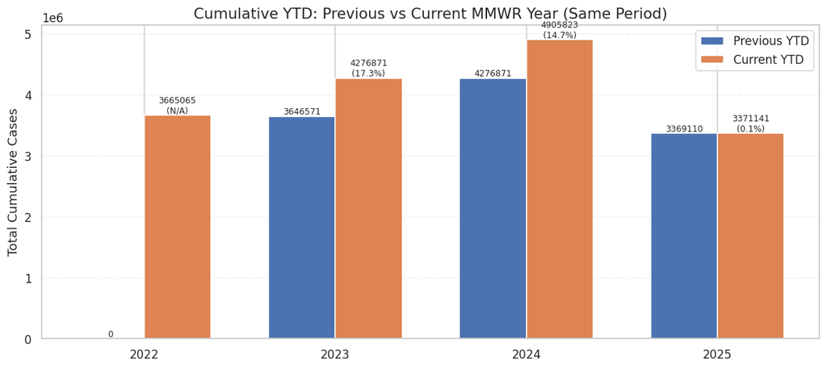

```
📊 Yearly YTD Summary with % Change:
```

|  | Year | Current_YTD | Previous_YTD | Start_Date | End_Date | Pct_Change (%) | Surge_Category |
| --- | --- | --- | --- | --- | --- | --- | --- |
| 0 | 2022 | 3665065.00 | 0.00 | 2022-01-03 | 2022-12-26 | NaN | No Previous Year |
| 1 | 2023 | 4276871.00 | 3646571.00 | 2023-01-02 | 2023-12-25 | 17.30 | Slight Increase |
| 2 | 2024 | 4905823.00 | 4276871.00 | 2024-01-01 | 2024-12-30 | 14.70 | Slight Increase |
| 3 | 2025 | 3371141.00 | 3369110.00 | 2025-01-06 | 2025-09-15 | 0.10 | Slight Increase |

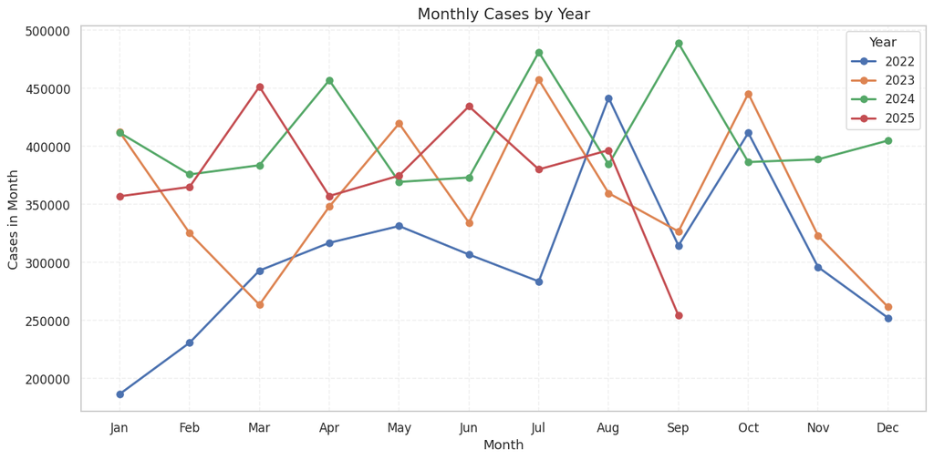

```
📊 Total Cases per Year with % Change:
```

|  | year | Total_Cases | Pct_Change (%) |
| --- | --- | --- | --- |
| 0 | 2022 | 3665065.00 | NaN |
| 1 | 2023 | 4276871.00 | 16.70 |
| 2 | 2024 | 4905823.00 | 14.70 |
| 3 | 2025 | 3371141.00 | -31.30 |

```python
# ==========================================
# Analysis 2: YTD Cumulative Cases Comparison with Surge Detection
# ==========================================

weekly_col = 'Current week'  # weekly cases
col_year   = 'year'
col_date   = 'date'
df = agg.copy()

# Yearly YTD summary
years = sorted(df[col_year].unique())
current_ytd_list = []
prev_ytd_list = []
start_dates = []
end_dates = []

for yr in years:
    df_cur = df[df[col_year] == yr].sort_values(col_date)
    start_date, end_date = df_cur[col_date].min(), df_cur[col_date].max()
    start_dates.append(start_date)
    end_dates.append(end_date)

    # Current YTD
    current_ytd = df_cur[weekly_col].sum()
    current_ytd_list.append(current_ytd)

    # Previous-year YTD for same period
    prev_year = yr - 1
    df_prev = df[(df[col_year] == prev_year) &
                 (df[col_date] >= start_date.replace(year=prev_year)) &
                 (df[col_date] <= end_date.replace(year=prev_year))]
    prev_ytd = df_prev[weekly_col].sum()
    prev_ytd_list.append(prev_ytd)

df_yearly = pd.DataFrame({
    'Year': years,
    'Current_YTD': current_ytd_list,
    'Previous_YTD': prev_ytd_list,
    'Start_Date': start_dates,
    'End_Date': end_dates
})

# % change from previous year
df_yearly["Pct_Change (%)"] = ((df_yearly["Current_YTD"] - df_yearly["Previous_YTD"]) /
                               df_yearly["Previous_YTD"] * 100).round(1)
df_yearly["Pct_Change (%)"] = df_yearly["Pct_Change (%)"].replace([np.inf, -np.inf], np.nan)

# Surge classification
def classify_change(pct):
    if pd.isna(pct):
        return "No Previous Year"
    if pct > 50:
        return "Severe Surge"
    elif pct > 20:
        return "Moderate Surge"
    elif pct > 0:
        return "Slight Increase"
    elif pct < -20:
        return "Large Decrease"
    else:
        return "Stable / Mild Change"

df_yearly["Surge_Category"] = df_yearly["Pct_Change (%)"].apply(classify_change)

# Yearly YTD bar chart
x = np.arange(len(df_yearly))
width = 0.35
fig, ax = plt.subplots(figsize=(11, 5))
prev_bars = ax.bar(x - width/2, df_yearly["Previous_YTD"], width, label="Previous YTD")
curr_bars = ax.bar(x + width/2, df_yearly["Current_YTD"], width, label="Current YTD")

for i, (b1, b2, pct) in enumerate(zip(prev_bars, curr_bars, df_yearly["Pct_Change (%)"])):
    ax.text(b1.get_x() + b1.get_width()/2, b1.get_height(), f"{int(b1.get_height())}",
            ha='center', va='bottom', fontsize=8)
    label_pct = f"({pct}%)" if not pd.isna(pct) else "(N/A)"
    ax.text(b2.get_x() + b2.get_width()/2, b2.get_height(), f"{int(b2.get_height())}\n{label_pct}",
            ha='center', va='bottom', fontsize=8)

ax.set_xticks(x)
ax.set_xticklabels(df_yearly['Year'].astype(str))
ax.set_title("Cumulative YTD: Previous vs Current MMWR Year (Same Period)")
ax.set_ylabel("Total Cumulative Cases")
ax.legend()
ax.grid(axis='y', linestyle='--', alpha=0.3)
plt.tight_layout()
plt.show()

# Display yearly summary table with % change
print("📊 Yearly YTD Summary with % Change:")
display(df_yearly)

# Monthly Cases Comparison per Year
df['month_num'] = df[col_date].dt.month
monthly = df.groupby([col_year, 'month_num'])[weekly_col].sum().reset_index()
years = monthly[col_year].unique()

fig, ax = plt.subplots(figsize=(12, 6))
for yr in sorted(years):
    df_plot = monthly[monthly[col_year] == yr]
    ax.plot(df_plot['month_num'], df_plot[weekly_col], marker='o', label=str(yr))

ax.set_xticks(range(1, 13))
ax.set_xticklabels(['Jan', 'Feb', 'Mar', 'Apr', 'May', 'Jun',
                    'Jul', 'Aug', 'Sep', 'Oct', 'Nov', 'Dec'])
ax.set_title("Monthly Cases by Year")
ax.set_ylabel("Cases in Month")
ax.set_xlabel("Month")
ax.legend(title="Year")
ax.grid(True, linestyle='--', alpha=0.3)
plt.tight_layout()
plt.show()

# Summary table: total cases per year
summary_total = df.groupby(col_year)[weekly_col].sum().reset_index()
summary_total = summary_total.rename(columns={weekly_col: 'Total_Cases'})

# Add % change column
summary_total['Pct_Change (%)'] = summary_total['Total_Cases'].pct_change() * 100
summary_total['Pct_Change (%)'] = summary_total['Pct_Change (%)'].round(1)
summary_total['Pct_Change (%)'] = summary_total['Pct_Change (%)'].replace([np.inf, -np.inf], np.nan)

print("📊 Total Cases per Year with % Change:")
display(summary_total)
```

Surge classification is as follows:

- Moderate Surge if %change >20%
- Severe Surge if %change >50% To make it easier to interpret.

Interpretation:

Actionable Insights:

Technical Skills for Analysis 2:

```
Peak & Seasonality Summary
```

| Label | Peak_Week | Peak_Value | Secondary_Peaks | Amplitude | Seasonality_Strength |
| --- | --- | --- | --- | --- | --- |
| Chlamydia trachomatis infection | 41 | 56248.60 | [9, 13, 18, 31] | 0.54 | Weak |
| Gonorrhea | 43 | 19668.60 | [31] | 0.57 | Weak |
| Campylobacteriosis | 28 | 3798.40 | [40] | 0.92 | Moderate |
| Hepatitis C, chronic, Probable | 36 | 4475.70 | [9, 17, 40] | 0.41 | Weak |
| Salmonellosis (excluding Salmonella Typhi infection and Salmonella Paratyphi infection) | 35 | 2440.60 | None | 1.21 | Moderate |
| Hepatitis C, chronic, Confirmed | 9 | 3251.20 | [17, 21, 40] | 0.53 | Weak |
| Coccidioidomycosis, Confirmed | 48 | 1636.30 | [3, 11] | 0.92 | Moderate |
| Invasive pneumococcal disease, all ages, Confirmed | 1 | 1013.50 | [3, 7, 48] | 1.11 | Moderate |
| Coccidioidomycosis, total | 48 | 1646.60 | [3, 8] | 1.04 | Moderate |
| Shigellosis | 34 | 721.60 | [39, 48] | 0.67 | Weak |
| Giardiasis | 36 | 687.40 | [40, 46] | 0.77 | Moderate |
| Pertussis | 32 | 423.60 | [21, 27, 48] | 0.77 | Moderate |
| Hepatitis B, chronic, Probable | 9 | 1064.40 | [14, 18, 36, 40, 48] | 0.49 | Weak |
| Shiga toxin-producing Escherichia coli (STEC) | 31 | 631.10 | None | 1.20 | Moderate |
| Syphilis, Primary and secondary | 13 | 406.00 | [8, 21, 32, 41] | 0.64 | Weak |
| Hepatitis B, chronic, Confirmed | 17 | 880.40 | [9, 13, 33, 39, 43, 48] | 0.56 | Weak |
| Cryptosporidiosis | 34 | 586.60 | None | 1.67 | Strong |
| Coccidioidomycosis, Total | 5 | 1585.40 | [17] | 1.58 | Strong |
| Tuberculosis | 33 | 223.00 | [21, 25, 41, 49] | 0.70 | Weak |
| Legionellosis | 31 | 274.60 | [35, 39] | 1.21 | Moderate |

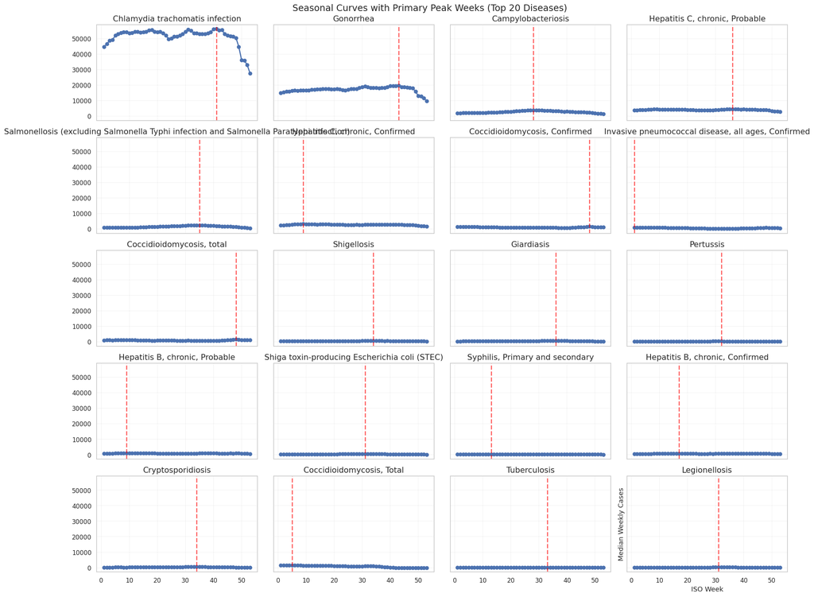

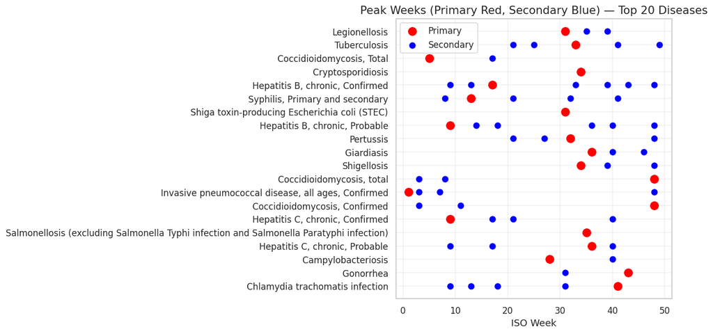

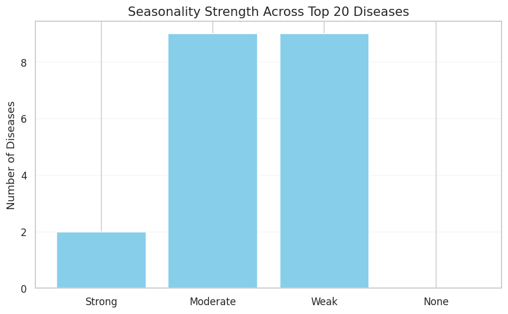

```python
# ==========================================
# Analysis 3: Seasonality & Peak Week Analysis
# ==========================================

from scipy.signal import find_peaks

weekly_col = 'Current week'
label_col  = 'Label'
date_col   = 'date'

# Validation
for col in [weekly_col, label_col, date_col]:
    if col not in agg.columns:
        raise ValueError(f"Missing required column: {col}")

if not np.issubdtype(agg[date_col].dtype, np.datetime64):
    raise TypeError("Column 'date' must be datetime.")

# Extract ISO week and year
agg["iso_week"] = agg[date_col].dt.isocalendar().week.astype(int)
agg["iso_year"] = agg[date_col].dt.isocalendar().year.astype(int)

# Select Top 20 Diseases
top20 = agg.groupby(label_col)[weekly_col].sum().nlargest(20).index

# Median Seasonal Curve
season = (
    agg[agg[label_col].isin(top20)]
    .groupby([label_col, "iso_week"])[weekly_col]
    .median()
    .unstack(fill_value=0)
)

season = season.reindex(columns=range(1, 54), fill_value=0)
season_smooth = season.rolling(7, center=True, min_periods=1, axis=1).mean()

# Peak Week Detection
peak_week = season_smooth.idxmax(axis=1)
peak_value = season_smooth.max(axis=1)

secondary_peaks = {}
for disease in season_smooth.index:
    series = season_smooth.loc[disease].values
    peaks, _ = find_peaks(series, distance=4, height=np.percentile(series, 60))
    sec = [p+1 for p in peaks if p+1 != peak_week[disease]]  # skip primary peak
    secondary_peaks[disease] = sec if sec else None

# 3. Seasonality Strength
median_val = season_smooth.median(axis=1).replace(0, np.nan)
amplitude = ((season_smooth.max(axis=1) - season_smooth.min(axis=1)) / median_val).fillna(0)

def classify_seasonality(a):
    if a >= 1.5: return "Strong"
    if a >= 0.7: return "Moderate"
    if a >= 0.3: return "Weak"
    return "None"

seasonality_strength = amplitude.apply(classify_seasonality)

# Summary Table
summary = pd.DataFrame({
    "Peak_Week": peak_week,
    "Peak_Value": peak_value.round(1),
    "Secondary_Peaks": secondary_peaks,
    "Amplitude": amplitude.round(2),
    "Seasonality_Strength": seasonality_strength
}).loc[top20]

print("Peak & Seasonality Summary")
display(summary)

# Multiple seasonal curves
n_cols = 4
n_rows = int(np.ceil(len(top20)/n_cols))
fig, axes = plt.subplots(n_rows, n_cols, figsize=(18, n_rows*3), sharex=True, sharey=True)
axes = axes.flatten()

for i, disease in enumerate(top20):
    axes[i].plot(season_smooth.columns, season_smooth.loc[disease], marker='o')
    axes[i].set_title(disease)
    axes[i].axvline(peak_week[disease], color='red', linestyle='--', alpha=0.6)
    axes[i].grid(alpha=0.2)

for j in range(i+1, len(axes)):
    fig.delaxes(axes[j])

fig.suptitle("Seasonal Curves with Primary Peak Weeks (Top 20 Diseases)", fontsize=16)
plt.xlabel("ISO Week")
plt.ylabel("Median Weekly Cases")
plt.tight_layout()
plt.show()

# Peak Week Dot Calendar
plt.figure(figsize=(12,6))
for idx, disease in enumerate(top20):
    plt.scatter(peak_week[disease], [idx], color='red', s=100, label='Primary' if idx==0 else "")
    if secondary_peaks[disease]:
        plt.scatter(secondary_peaks[disease], [idx]*len(secondary_peaks[disease]), color='blue', s=50, label='Secondary' if idx==0 else "")

plt.yticks(range(len(top20)), top20)
plt.xlabel("ISO Week")
plt.title("Peak Weeks (Primary Red, Secondary Blue) — Top 20 Diseases")
plt.legend()
plt.grid(alpha=0.3)
plt.tight_layout()
plt.show()

# Seasonality Strength Bar Chart
strength_order = ["Strong", "Moderate", "Weak", "None"]
strength_counts = seasonality_strength.value_counts().reindex(strength_order, fill_value=0)

plt.figure(figsize=(8,5))
plt.bar(strength_counts.index, strength_counts.values, color='skyblue')
plt.ylabel("Number of Diseases")
plt.title("Seasonality Strength Across Top 20 Diseases")
plt.grid(axis='y', alpha=0.2)
plt.tight_layout()
plt.show()
```

The following calculations are used:

- Median Seasonal Curve - For each disease, the median weekly case count is calculated across all available years for each ISO week (weeks 1–53). This shows the "typical" weekly pattern to reduces outlier influence
- Smoothing - A rolling average applied to the median seasonal curve to reduce short-term fluctuations or “noise" so that peaks can easily be detected visually.
- Primary Peak - Highest weekly value in a year.
- Secondary Peak - Some diseases may have more than one seasonal peak (bimodal or multimodal patterns).
- Seasonality Strength - Measures how strongly seasonal a disease is. This can help in prioritizing and planning actions/interventions.

Interpretation:

Actionable Insights:

- Targeted interventions should be done during peak weeks such as conducting vaccination, awareness campaigns, and testing for diseases with strong/moderate seasonality 1–2 weeks before peak weeks.
- Year-Round Surveillance for Weakly Seasonal Diseases. Continuous monitoring and public education are necessary throughout the year.
- Resource Allocation Based on Seasonality Strength: Strongly seasonal diseases → surge staffing during peak weeks, minimal off-season. Weakly seasonal → maintain consistent baseline resources year-round.
- For diseases with multiple secondary peaks, multiple interventions may be required per year.

Techincal Skills for Analysis 3:

- **Seasonality Analysis**
- **Disease Patterns**
4. **US States Case Distribution** - Identifying and visualizing top areas is important to determine hotspots and track temporal trends and analysis.

```python
# ============================================================
# Analysis 4: US States Case Distribution
# ============================================================

# State-level aggregation
agg_state = (
    df_clean.groupby(['Label', 'date', 'Reporting Area'], as_index=False)[CURRENT]
    .sum()
    .sort_values(['Label', 'Reporting Area', 'date'])
    .reset_index(drop=True)
)

agg_state['Reporting Area'] = (
    agg_state['Reporting Area'].astype(str).str.strip().str.title()
)

import plotly.graph_objects as go
from plotly.subplots import make_subplots

state_col = "Reporting Area"
case_col = "Current week"
df_state = agg_state.copy()

# US State list
state_to_abbrev = {
    'Alabama':'AL','Alaska':'AK','Arizona':'AZ','Arkansas':'AR','California':'CA',
    'Colorado':'CO','Connecticut':'CT','Delaware':'DE','Florida':'FL','Georgia':'GA',
    'Hawaii':'HI','Idaho':'ID','Illinois':'IL','Indiana':'IN','Iowa':'IA','Kansas':'KS',
    'Kentucky':'KY','Louisiana':'LA','Maine':'ME','Maryland':'MD','Massachusetts':'MA',
    'Michigan':'MI','Minnesota':'MN','Mississippi':'MS','Missouri':'MO','Montana':'MT',
    'Nebraska':'NE','Nevada':'NV','New Hampshire':'NH','New Jersey':'NJ','New Mexico':'NM',
    'New York':'NY','North Carolina':'NC','North Dakota':'ND','Ohio':'OH','Oklahoma':'OK',
    'Oregon':'OR','Pennsylvania':'PA','Rhode Island':'RI','South Carolina':'SC',
    'South Dakota':'SD','Tennessee':'TN','Texas':'TX','Utah':'UT','Vermont':'VT',
    'Virginia':'VA','Washington':'WA','West Virginia':'WV','Wisconsin':'WI','Wyoming':'WY'
}

valid_states = list(state_to_abbrev.keys())
df_state = df_state[df_state[state_col].isin(valid_states)]

# Total Cases by state
state_cases = (
    df_state.groupby(state_col)[case_col]
    .sum()
    .reset_index()
)

total_cases = state_cases[case_col].sum()

state_cases["Percentage_of_US"] = (
    state_cases[case_col] / total_cases * 100
).round(2)

state_cases["State_Abbrev"] = state_cases[state_col].map(state_to_abbrev)
state_cases = state_cases.sort_values("Percentage_of_US", ascending=False)

# Top 10 States
top10 = state_cases.head(10)

# Visualization
fig = make_subplots(
    rows=1, cols=2,
    column_widths=[0.65, 0.35],
    specs=[[{"type": "choropleth"}, {"type": "bar"}]],
    subplot_titles=("US States: % of Total Cases", "Top 10 States: Total Weekly Cases")
)

# Choropleth Map
choropleth = go.Choropleth(
    locations=state_cases["State_Abbrev"],
    z=state_cases["Percentage_of_US"],
    locationmode="USA-states",
    colorscale="Reds",
    colorbar=dict(title="% of US Cases"),
    text=state_cases.apply(
        lambda r: f"{r[state_col]}<br>Total Cases: {r[case_col]:,}<br>{r['Percentage_of_US']}%",
        axis=1
    ),
    hoverinfo="text"
)

fig.add_trace(choropleth, row=1, col=1)

# Bar Chart
bar = go.Bar(
    y=top10[state_col],
    x=top10[case_col],
    orientation="h",
    text=top10["Percentage_of_US"].astype(str) + "%",
    textposition="auto",
    marker_color="crimson"
)

fig.add_trace(bar, row=1, col=2)

fig.update_yaxes(autorange="reversed", row=1, col=2)

# Layout
fig.update_layout(
    title="US States: Weekly Case Contribution Dashboard",
    height=800,
    showlegend=False,
    geo=dict(scope="usa", projection_scale=1.2)
)

fig.show()
```

[interactive chart not shown]

Identifying and visualizing top areas by using a choropleth map.

Interpretation:

- California (13.14%) and Florida (11.27%) are the highest contributors to national weekly cases.
- The top 10 states together account for roughly 57% of national weekly cases, indicating a concentration in a few high-burden states.
- High-burden states are distributed across the West (California, Arizona), Southeast (Florida, Georgia, South Carolina, Alabama), and Northeast (New York, Pennsylvania), likely reflecting population density and mobility patterns.

Actionable Insights:

- Prioritize Resources for High-Burden States. Allocate healthcare resources, testing, hospital staffing, and vaccination campaigns to the top 10 states, which together carry over half of the national weekly cases.
- States with 2–3% contributions (e.g., Washington, Missouri, Wisconsin) should be closely monitored for potential upward trends.

Technical Skills for Analysis 4:

```python
# ==========================================
# Analysis 5: Flag Analysis
# ==========================================

from IPython.display import display

# Identify date column
df_raw.columns = df_raw.columns.str.strip()

if 'Current MMWR Year' in df_raw.columns and 'MMWR WEEK' in df_raw.columns:
    df_raw['date'] = pd.to_datetime(
        df_raw['Current MMWR Year'].astype(str) + '-W' + df_raw['MMWR WEEK'].astype(str) + '-1',
        format='%Y-W%W-%w'
    )
else:
    raise ValueError("Year or Week column missing for date conversion.")

# Identify flag columns
flag_cols = [c for c in df_raw.columns if 'flag' in c.lower()]
if not flag_cols:
    print("⚠️ No flag columns detected.")
else:
    print(f"Detected flag columns: {flag_cols}\n")

    # Aggregate flags by Label + date
    agg_flag = (
        df_raw.groupby(['Label', 'date'], as_index=False)[flag_cols]
              .agg(lambda x: x.mode()[0] if not x.mode().empty else None)  # most common flag
    )

    df_flags = pd.merge(
        agg[['Label', 'date']],  # your cleaned weekly dataset
        agg_flag,
        on=['Label', 'date'],
        how='left'
    )

# Summary table for flag columns
    flag_summary = []
    for f in flag_cols:
        counts = df_flags[f].value_counts(dropna=False)
        pct = df_flags[f].value_counts(normalize=True, dropna=False) * 100
        summary = pd.DataFrame({
            'Flag Value': counts.index,
            'Count': counts.values,
            'Percentage': pct.values.round(2),
            'Column': f
        })
        summary['Rare Flag'] = summary['Percentage'] < 5
        flag_summary.append(summary)

# Output table
    flag_summary_df = pd.concat(flag_summary, ignore_index=True)
    display(flag_summary_df.sort_values(['Column','Percentage'], ascending=[True, False]))
```

```
Detected flag columns: ['Current week, flag', 'Previous 52 weeks Max, flag', 'Cumulative YTD Current MMWR Year, flag', 'Cumulative YTD Previous MMWR Year, flag']
```

|  | Flag Value | Count | Percentage | Column | Rare Flag |
| --- | --- | --- | --- | --- | --- |
| 6 | - | 15196 | 97.77 | Cumulative YTD Current MMWR Year, flag | False |
| 7 | NaN | 178 | 1.15 | Cumulative YTD Current MMWR Year, flag | True |
| 8 | N | 169 | 1.09 | Cumulative YTD Current MMWR Year, flag | True |
| 9 | - | 14719 | 94.70 | Cumulative YTD Previous MMWR Year, flag | False |
| 10 | N | 238 | 1.53 | Cumulative YTD Previous MMWR Year, flag | True |
| 11 | NP | 208 | 1.34 | Cumulative YTD Previous MMWR Year, flag | True |
| 12 | NN | 200 | 1.29 | Cumulative YTD Previous MMWR Year, flag | True |
| 13 | NaN | 178 | 1.15 | Cumulative YTD Previous MMWR Year, flag | True |
| 0 | - | 15365 | 98.85 | Current week, flag | False |
| 1 | NaN | 178 | 1.15 | Current week, flag | True |
| 2 | - | 11761 | 75.67 | Previous 52 weeks Max, flag | False |
| 3 | NC | 2037 | 13.11 | Previous 52 weeks Max, flag | False |
| 4 | None | 1567 | 10.08 | Previous 52 weeks Max, flag | False |
| 5 | NaN | 178 | 1.15 | Previous 52 weeks Max, flag | True |

We analyze flags by checking on the flag columns and compute the counts and percentages for each flag value, then we mark if that specific flag is rare in our dataset.

Interpretation:

- Most rows have standard flags across all columns, indicating generally reliable and complete reporting.
- Small but notable proportions of missing data (NaN, N, NP, NN) occur in ~1–1.5% of rows for weekly and cumulative counts, suggesting some incomplete or provisional reporting.
- The Previous 52 weeks Max, flag column shows higher non-standard flags: NC (~13%) and None (~10%), which is substantial and may impact trend analyses or comparisons across weeks. These should be clarified with the data source.
- Overall, while most data is reliable, there are identifiable gaps or provisional entries that may affect analyses of cumulative or historical maxima.

Actionable Insights:

- Document all rare or non-standard flags and understand their definitions from the source.
- Consider filtering, imputing, or separately analyzing rows with provisional/missing flags (NaN, N, NP, NN) to avoid bias in cumulative counts or trends.
- Pay particular attention to Previous 52 weeks Max values marked NC or None as they could distort trend or peak analyses.
- Maintain flag monitoring as part of routine data quality checks, especially when updating dashboards, visualizations, or forecasting models.

Technical Skills for Analysis 5:

- **Quality Assessment** - Shows ability to assess data completeness, provisional values, and anomalies.
- **Data Governance** - Understanding the meaning of flags: which are provisional, missing, or unreliable.

# **Results and Discussions**

**Summary of Results**

**Skills/Techiques Used**

1. **Data Handling & Preprocessing**
- Cleaning and aggregating weekly-level CDC NNDSS data.
- Feature engineering for analysis.
- Handling missing data and maintaining data consistency across multiple aggregation levels.
2. **Exploratory Data Analysis (EDA)**
- National and state-level disease trends.
- Year-to-year and monthly cumulative comparisons.
- Detection of outliers, anomalies, and rare events.
3. **Time-Series Analysis**
- Year-to-date cumulative comparisons (YTD vs previous year).
- Monthly trend analysis for magnitude comparison.
- Seasonal pattern detection using median seasonal curves.
4. **Seasonality & Peak Detection**
- Identifying primary and secondary peak weeks.
- Calculating seasonality strength and classifying diseases (weak, moderate, strong).
- Using rolling averages and peak-finding algorithms for signal smoothing and peak detection.
5. **Geospatial Analysis**
- Mapping disease contribution by state using choropleth and bar charts.
- Interpreting high-burden regions for public health decision-making.
6. **Data Quality & Flag Analysis**
- Detecting provisional, missing, or special-handling data via flag columns.
- Summarizing, quantifying, and interpreting impact on trend analysis.
7. **Visualization & Reporting**
- Multi-faceted visualization: bar charts, line plots, seasonal curves, choropleth maps.
- Combining visual insights with summary tables for actionable interpretation.
- Clear communication of analytical findings with practical recommendations.
8. **Analytical & Critical Thinking**
- Translating raw data into actionable insights for disease surveillance and public health planning.
- Integrating multiple analyses (temporal, spatial, seasonal) to form a cohesive story.